# Operating Models Summary

North Atlantic Swordfish MSE

Adrian Hordyk adrian@bluematterscience.com

March 14, 2020

# 1 Operating Model Scenarios

## 1.1 Base Case Model

Table 1. Key parameter values for the base case analysis. The column names are: Natural mortality (M) - fixed parameter; standard error of recruitment deviations (sigmaR) - fixed parameter; Steepness (h) - estimated in the base case model; Coefficient of variation for the indices (CPUE CV) - varied between indices and years (range of values shown here); Effective sample size of length composition (Len. Comp. Eff. Samp. Size) - fixed; Q Increase assumed for indices (Q increase); Environmental covariate included for some indices (Env. Covariate).

| M | sigmaR | h | CPUE CV | Len. Comp. Eff. Samp. Size | Q increase | Env. Covariate |
| --- | --- | --- | --- | --- | --- | --- |
| 0.2 | 0.2 | 0.88356 | 0.16 - 0.38 | 1 | FALSE | TRUE |

## 1.2 Uncertainty Grid

| M | sigmaR | h | CPUE CV | Len. Comp. Eff. Samp. Size | Q increase | Env. Covariate |
| --- | --- | --- | --- | --- | --- | --- |
| 0.1 | 0.2 | 0.60 | 0.3 | 2 | FALSE | FALSE |
| 0.2 | 0.6 | 0.75 | 0.6 | 20 | 1.01 | TRUE |
| 0.3 |  | 0.90 |  |  |  |  |

# 2 OM Parameter Table

Table 3. The parameters for the base case and 288 models from the uncertainty grid. Filters at the top of each column can be used to subset the results.

| OM | M | sigmaR | h | CPUE CV | Len. Comp. Eff. Samp. Size | Q increase | Env. Covariate | Converged |
| --- | --- | --- | --- | --- | --- | --- | --- | --- |
| base_case | 0.2 | 0.2 | 0.88356 | 0.2701595 | 1 | 1 | TRUE | TRUE |
| 1 | 0.1 | 0.2 | 0.6 | 0.3 | 2 | 1 | FALSE | FALSE |
| 2 | 0.1 | 0.6 | 0.75 | 0.3 | 2 | 1 | FALSE | FALSE |
| 3 | 0.1 | 0.6 | 0.75 | 0.6 | 2 | 1.01 | FALSE | TRUE |
| 4 | 0.2 | 0.6 | 0.75 | 0.6 | 2 | 1.01 | FALSE | TRUE |
| 5 | 0.3 | 0.6 | 0.75 | 0.6 | 2 | 1.01 | FALSE | TRUE |
| 6 | 0.1 | 0.2 | 0.9 | 0.6 | 2 | 1.01 | FALSE | TRUE |
| 7 | 0.2 | 0.2 | 0.9 | 0.6 | 2 | 1.01 | FALSE | TRUE |
| 8 | 0.3 | 0.2 | 0.9 | 0.6 | 2 | 1.01 | FALSE | TRUE |
| 9 | 0.1 | 0.6 | 0.9 | 0.6 | 2 | 1.01 | FALSE | TRUE |

[output cut: 279 more lines]

# 3 Likelihood Value Table

Table 4. The total and component likelihood values for the base case model and the 173 converged models from the uncertainty grid. Filters at the top of each column can be used to subset the results.

| OM | Total | Catch | Survey | Mean_body_wt | Length_comp | Recruitment |
| --- | --- | --- | --- | --- | --- | --- |
| base_case | 245.933 | 2.72972e-09 | -251.131 | 122.905 | 426.197 | -52.8302 |
| 3 | -64.8504 | 8.1816e-12 | -245.7 | 122.361 | 72.9009 | -14.4322 |
| 4 | -76.99 | 7.49852e-12 | -234.998 | 122.106 | 53.1243 | -17.2567 |
| 5 | -74.4984 | 7.79451e-12 | -232.505 | 122.37 | 52.9296 | -17.3094 |
| 6 | -91.7313 | 8.5661e-11 | -235.257 | 122.969 | 67.605 | -47.0545 |
| 7 | -105.354 | 3.92018e-10 | -232.565 | 122.4 | 52.3193 | -47.5181 |
| 8 | -100.018 | 2.3907e-10 | -227.19 | 121.93 | 52.9346 | -47.707 |
| 9 | -68.2785 | 1.95995e-11 | -245.172 | 121.904 | 70.0075 | -15.0495 |
| 10 | -77.3615 | 3.55805e-11 | -235.038 | 122.307 | 52.6169 | -17.2734 |
| 11 | -73.9782 | 2.54305e-11 | -231.933 | 122.303 | 52.97 | -17.332 |

[output cut: 164 more lines]

# 4 Reference Points Table

Table 5. Summary table of the biological reference points for the base case model and the 173 converged models from the uncertainty grid.

| OM | MSY | SBMSY | FMSY | F/FMSY | SB/SBMSY | SBMMSY/SB0 | Depletion |
| --- | --- | --- | --- | --- | --- | --- | --- |
| base_case | 12708 | 21263.1 | 0.17 | 0.86 | 1.26 | 0.18 | 0.23 |
| 3 | 12126.2 | 110458 | 0.06 | 1.14 | 0.92 | 0.29 | 0.26 |
| 4 | 14562.6 | 42293.2 | 0.12 | 0.87 | 1.03 | 0.25 | 0.26 |
| 5 | 16243.4 | 21085.7 | 0.16 | 0.69 | 1.31 | 0.23 | 0.3 |
| 6 | 11385.7 | 65693.2 | 0.09 | 1.15 | 0.99 | 0.22 | 0.22 |
| 7 | 12624.4 | 20071.7 | 0.18 | 0.85 | 1.26 | 0.18 | 0.22 |
| 8 | 14282.6 | 9231.18 | 0.24 | 0.61 | 1.99 | 0.15 | 0.29 |
| 9 | 12737.3 | 73607.7 | 0.09 | 0.97 | 1.06 | 0.22 | 0.24 |
| 10 | 15448.9 | 24779.1 | 0.18 | 0.68 | 1.38 | 0.17 | 0.24 |
| 11 | 17906.4 | 11618.8 | 0.24 | 0.51 | 2 | 0.15 | 0.29 |

[output cut: 164 more lines]

# 5 SB/SB<sub>MSY</sub> Timeseries Plots

Time-series plots of the spawning biomass (SB) relative to spawning biomass corresponding with maximum sustainable yield (SB<sub>MSY</sub>) for the seven factors examined in the uncertainty grid.

## 5.1 Natural Mortality

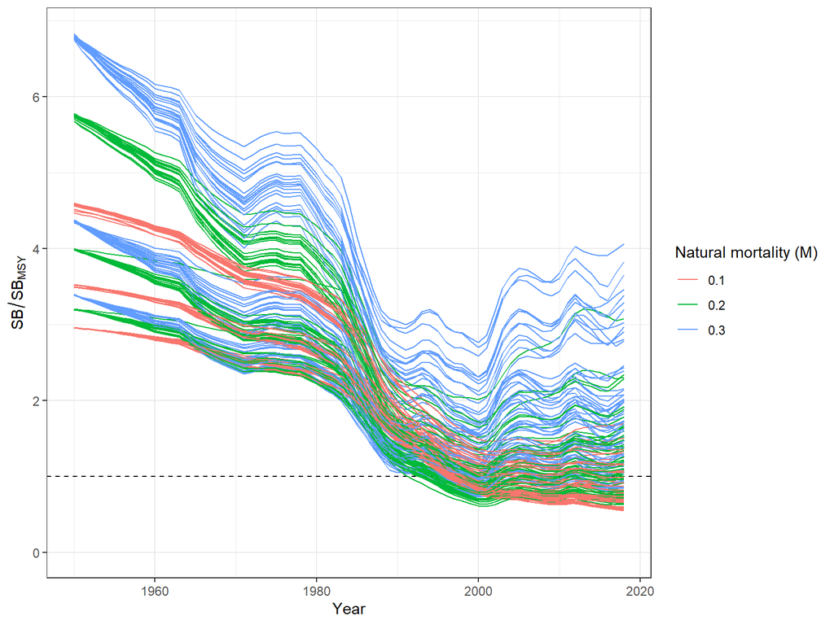

Figure 1. Predicted spawning biomass (SB) relative to spawning biomass at maximum sustainable yield (SB<sub>MSY</sub>) for the 173 converged OMs from the uncertainty grid with the 3 levels of Natural mortality (M) shown as coloured lines.

## 5.2 Recruitment Variability

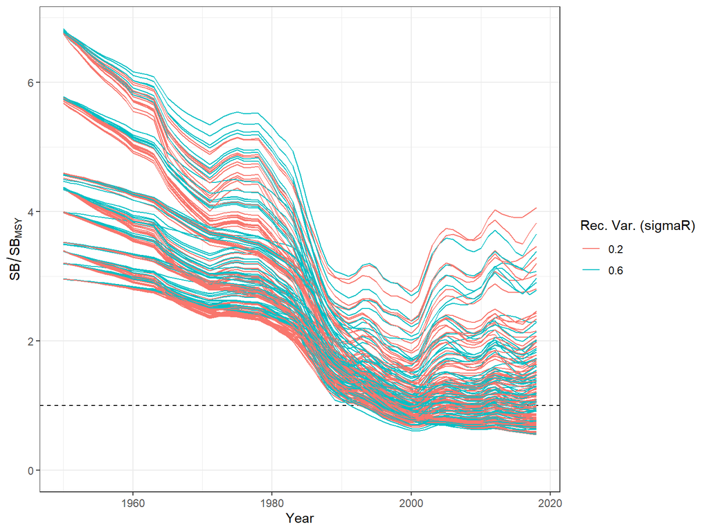

Figure 2. Predicted spawning biomass (SB) relative to spawning biomass at maximum sustainable yield (SB<sub>MSY</sub>) for the 173 converged OMs from the uncertainty grid with the 2 levels of Rec. Var. (sigmaR) shown as coloured lines.

## 5.3 Steepness

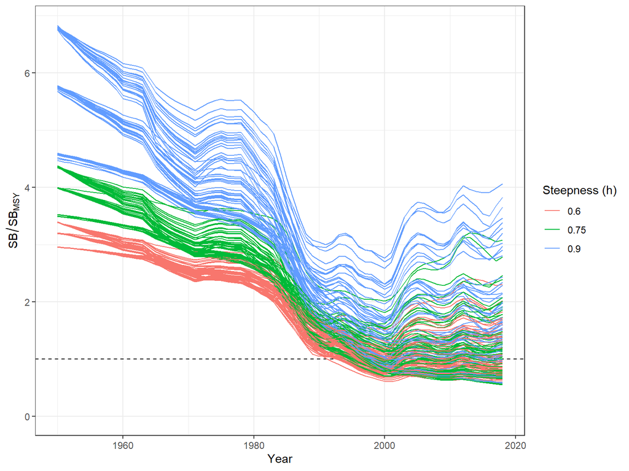

Figure 3. Predicted spawning biomass (SB) relative to spawning biomass at maximum sustainable yield (SB<sub>MSY</sub>) for the 173 converged OMs from the uncertainty grid with the 3 levels of Steepness (h) shown as coloured lines.

## 5.4 CPUE CV

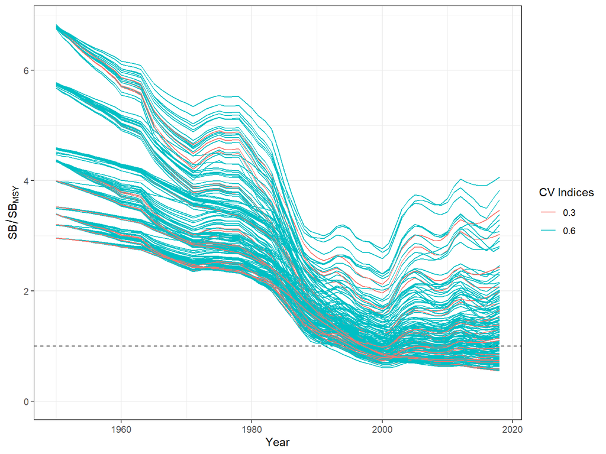

Figure 4. Predicted spawning biomass (SB) relative to spawning biomass at maximum sustainable yield (SB<sub>MSY</sub>) for the 173 converged OMs from the uncertainty grid with the 2 levels of CV Indices shown as coloured lines.

## 5.5 Length Comp. ESS

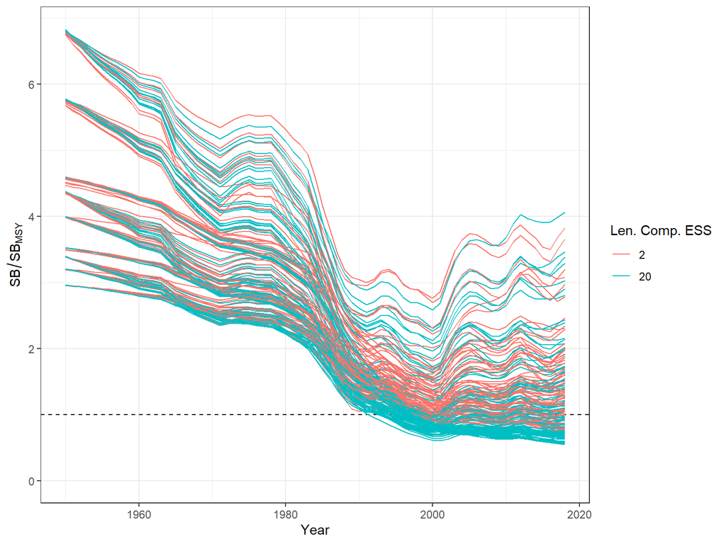

Figure 5. Predicted spawning biomass (SB) relative to spawning biomass at maximum sustainable yield (SB<sub>MSY</sub>) for the 173 converged OMs from the uncertainty grid with the 2 levels of Len. Comp. ESS shown as coloured lines.

## 5.6 Catchability Increase

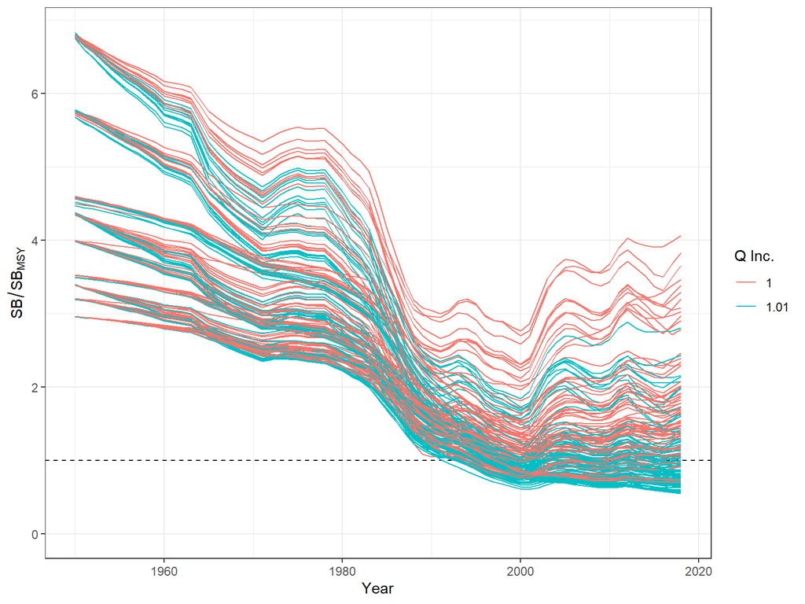

Figure 6. Predicted spawning biomass (SB) relative to spawning biomass at maximum sustainable yield (SB<sub>MSY</sub>) for the 173 converged OMs from the uncertainty grid with the 2 levels of Q Inc. shown as coloured lines.

## 5.7 Environmental Covariate

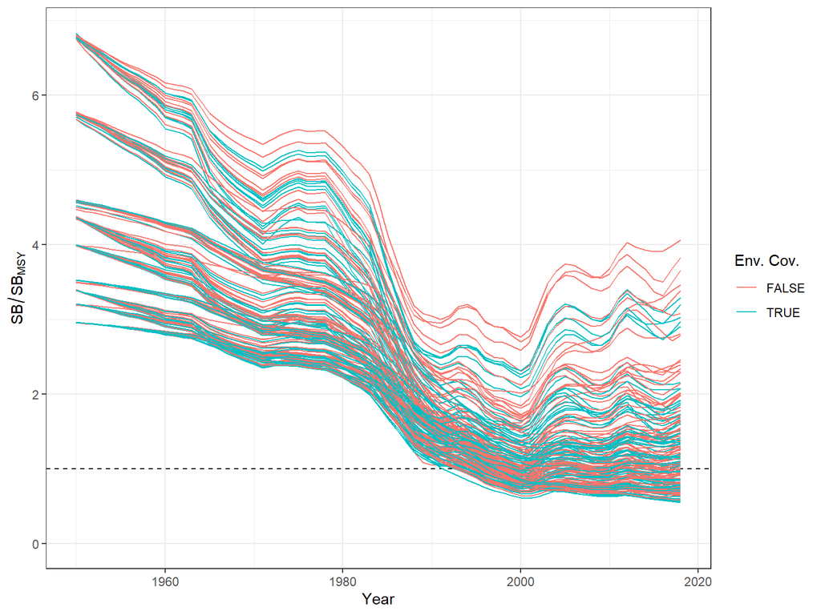

Figure 7. Predicted spawning biomass (SB) relative to spawning biomass at maximum sustainable yield (SB<sub>MSY</sub>) for the 173 converged OMs from the uncertainty grid with the 2 levels of Env. Cov. shown as coloured lines.

# 6 Current SB/SB<sub>MSY</sub> Boxplots

Bivariate boxplots of the spawning biomass (SB) relative to spawning biomass corresponding with maximum sustainable yield (SB<sub>MSY</sub>) for the factors examined in the uncertainty grid.

## 6.1 Natural Mortality

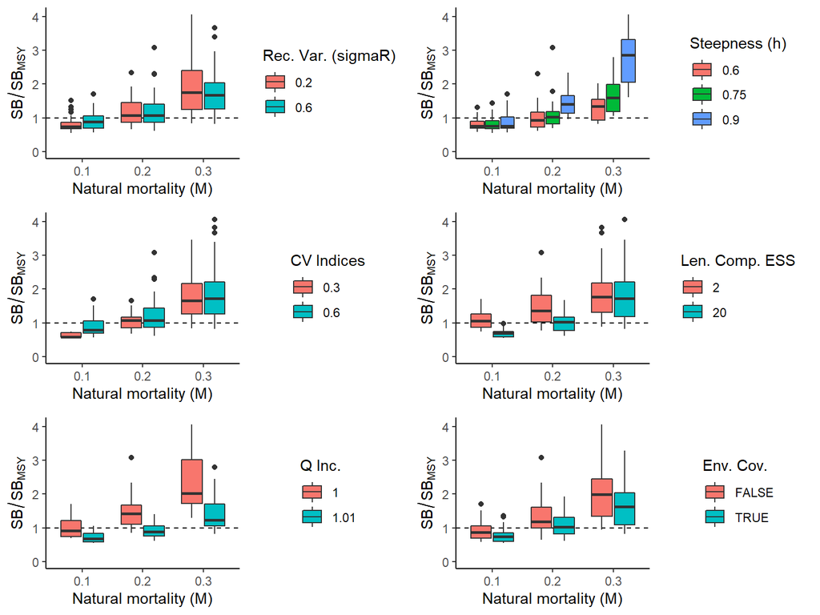

Figure 8. Boxplots of predicted spawning biomass (SB) relative to spawning biomass at maximum sustainable yield (SB<sub>MSY</sub>) for the 173 converged OMs from the uncertainty grid with the 3 levels of Natural Mortality shown as factors on the x-axis and colours indicating the other factors.

## 6.2 Recruitment Variability

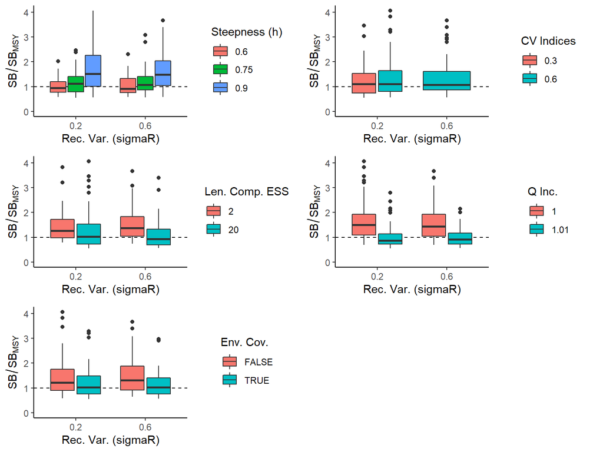

Figure 9. Boxplots of predicted spawning biomass (SB) relative to spawning biomass at maximum sustainable yield (SB<sub>MSY</sub>) for the 173 converged OMs from the uncertainty grid with the 2 levels of Recruitment Variability shown as factors on the x-axis and colours indicating the other factors.

## 6.3 Steepness

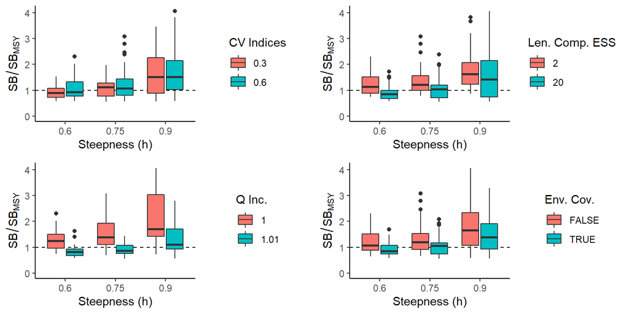

Figure 10. Boxplots of predicted spawning biomass (SB) relative to spawning biomass at maximum sustainable yield (SB<sub>MSY</sub>) for the 173 converged OMs from the uncertainty grid with the 3 levels of Steepness shown as factors on the x-axis and colours indicating the other factors.

## 6.4 CPUE CV

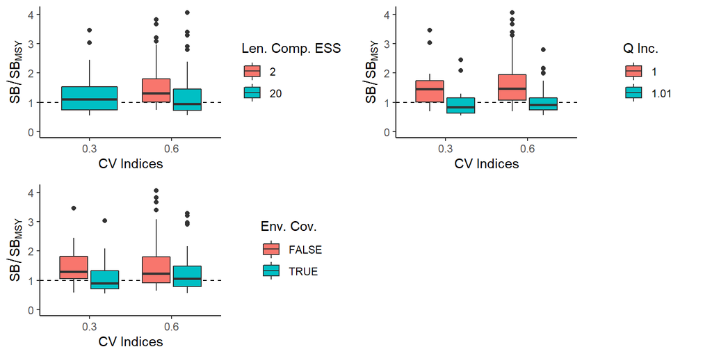

Figure 11. Boxplots of predicted spawning biomass (SB) relative to spawning biomass at maximum sustainable yield (SB<sub>MSY</sub>) for the 173 converged OMs from the uncertainty grid with the 2 levels of CV Indices shown as factors on the x-axis and colours indicating the other factors.

## 6.5 Length Comp. ESS

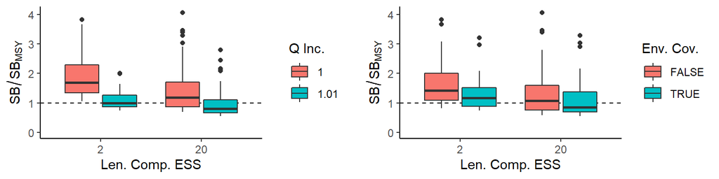

Figure 12. Boxplots of predicted spawning biomass (SB) relative to spawning biomass at maximum sustainable yield (SB<sub>MSY</sub>) for the 173 converged OMs from the uncertainty grid with the 2 levels of Length Composition Effective Sample Size shown as factors on the x-axis and colours indicating the other factors.

## 6.6 Catchability Increase

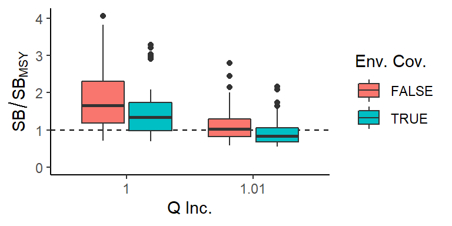

Figure 13. Boxplots of predicted spawning biomass (SB) relative to spawning biomass at maximum sustainable yield (SB<sub>MSY</sub>) for the 173 converged OMs from the uncertainty grid with the 2 levels of Q Increase shown as factors on the x-axis and colours indicating the other factors.